# HW7

Craig Alder

4/5/2017

Recall the NHANES dataset that we used in Lesson 10.

```r
library(tidyverse)
```

```r
library(class)
library(rpart)
library(NHANES)
library(RColorBrewer)
library(plot3D)
library(parallel)
library(randomForestSRC)
library(ggRandomForests)
library(mosaic)
library(ggplot2)
library(HistData)
library(car)
library(stargazer)
# Create the NHANES dataset again

people <- NHANES %>% dplyr::select(DaysMentHlthBad, PhysActive, AlcoholYear, Age, SleepHrsNight, SleepTrouble)
na.omit(people)
```

```
## # A tibble: 5,908 × 6
##    DaysMentHlthBad PhysActive AlcoholYear   Age SleepHrsNight SleepTrouble
##              <int>     <fctr>       <int> <int>         <int>       <fctr>
## 1               15         No           0    34             4          Yes
## 2               15         No           0    34             4          Yes
## 3               15         No           0    34             4          Yes
## 4               10         No          20    49             8          Yes
## 5                3        Yes          52    45             8           No
## 6                3        Yes          52    45             8           No
## 7                3        Yes          52    45             8           No
## 8                0        Yes         100    66             7           No
## 9                0        Yes         104    58             5           No
## 10               0        Yes         364    54             4          Yes
## # ... with 5,898 more rows
```

```r
glimpse(people)
```

```
## Observations: 10,000
## Variables: 6
## $ DaysMentHlthBad <int> 15, 15, 15, NA, 10, NA, NA, 3, 3, 3, 0, 0, 0, ...
## $ PhysActive      <fctr> No, No, No, NA, No, NA, NA, Yes, Yes, Yes, Ye...
## $ AlcoholYear     <int> 0, 0, 0, NA, 20, NA, NA, 52, 52, 52, 100, 104,...
## $ Age             <int> 34, 34, 34, 4, 49, 9, 8, 45, 45, 45, 66, 58, 5...
## $ SleepHrsNight   <int> 4, 4, 4, NA, 8, NA, NA, 8, 8, 8, 7, 5, 4, NA, ...
## $ SleepTrouble    <fctr> Yes, Yes, Yes, NA, Yes, NA, NA, No, No, No, N...
```

```r
class(people)
```

```
## [1] "tbl_df"     "tbl"        "data.frame"
```

```r
# Convert back to dataframe
people <- as.data.frame(people)
glimpse(people)
```

```
## Observations: 10,000
## Variables: 6
## $ DaysMentHlthBad <int> 15, 15, 15, NA, 10, NA, NA, 3, 3, 3, 0, 0, 0, ...
## $ PhysActive      <fctr> No, No, No, NA, No, NA, NA, Yes, Yes, Yes, Ye...
## $ AlcoholYear     <int> 0, 0, 0, NA, 20, NA, NA, 52, 52, 52, 100, 104,...
## $ Age             <int> 34, 34, 34, 4, 49, 9, 8, 45, 45, 45, 66, 58, 5...
## $ SleepHrsNight   <int> 4, 4, 4, NA, 8, NA, NA, 8, 8, 8, 7, 5, 4, NA, ...
## $ SleepTrouble    <fctr> Yes, Yes, Yes, NA, Yes, NA, NA, No, No, No, N...
```

```r
# Convert factors to numeric - the packages just seem to work better that way
#health
people$DaysMentHlthBad <- as.numeric(people$DaysMentHlthBad)
people$PhysActive <- as.numeric(people$PhysActive)
people$AlcoholYear <- as.numeric(people$AlcoholYear)
#demographics
people$Age <- as.numeric(people$Age)

#sleep
people$SleepTrouble <- as.numeric(people$SleepTrouble)
people$SleepHrsNight <- as.numeric(people$SleepHrsNight)

people <- na.omit(people)

glimpse(people)
```

```
## Observations: 5,908
## Variables: 6
## $ DaysMentHlthBad <dbl> 15, 15, 15, 10, 3, 3, 3, 0, 0, 0, 0, 7, 0, 0, ...
## $ PhysActive      <dbl> 1, 1, 1, 1, 2, 2, 2, 2, 2, 2, 2, 1, 1, 2, 2, 2...
## $ AlcoholYear     <dbl> 0, 0, 0, 20, 52, 52, 52, 100, 104, 364, 0, 104...
## $ Age             <dbl> 34, 34, 34, 49, 45, 45, 45, 66, 58, 54, 50, 33...
## $ SleepHrsNight   <dbl> 4, 4, 4, 8, 8, 8, 8, 7, 5, 4, 7, 6, 6, 7, 7, 8...
## $ SleepTrouble    <dbl> 2, 2, 2, 2, 1, 1, 1, 1, 1, 2, 1, 1, 2, 1, 1, 1...
```

1. In the dataset there is a discrete variable called SleepTrouble indicating whether each participant has trouble sleeping or not. You are going to build a set of classifiers for this dependent variable. You may use any (set of) independent variable(s) you like except for the variable callsed SleepHrsNight.

**Null Model**

```r
RegModel1 <-
  lm(SleepTrouble~DaysMentHlthBad + PhysActive + AlcoholYear + Age,
   data=people)
summary(RegModel1)
```

```
##
## Call:
## lm(formula = SleepTrouble ~ DaysMentHlthBad + PhysActive + AlcoholYear +
##     Age, data = people)
##
## Residuals:
##     Min      1Q  Median      3Q     Max
## -0.7099 -0.2681 -0.2019  0.4179  0.8860
##
## Coefficients:
##                   Estimate Std. Error t value Pr(>|t|)
## (Intercept)      1.037e+00  2.705e-02  38.348  < 2e-16 ***
## DaysMentHlthBad  1.236e-02  7.091e-04  17.425  < 2e-16 ***
## PhysActive       1.896e-02  1.163e-02   1.631  0.10294
## AlcoholYear     -1.453e-04  5.528e-05  -2.629  0.00859 **
## Age              3.473e-03  3.414e-04  10.175  < 2e-16 ***
## ---
## Signif. codes:  0 '***' 0.001 '**' 0.01 '*' 0.05 '.' 0.1 ' ' 1
##
## Residual standard error: 0.4302 on 5903 degrees of freedom
## Multiple R-squared:  0.06147,    Adjusted R-squared:  0.06084
## F-statistic: 96.66 on 4 and 5903 DF,  p-value: < 2.2e-16
```

My current model explains about 6% of the variance in the outcome variable. Each independent variable is statistically significant at p<.01 except the measure for physical activity. This model doesn’t explain very much right now, so it will be interesting to see how different methods change the predictive ability of these variables.

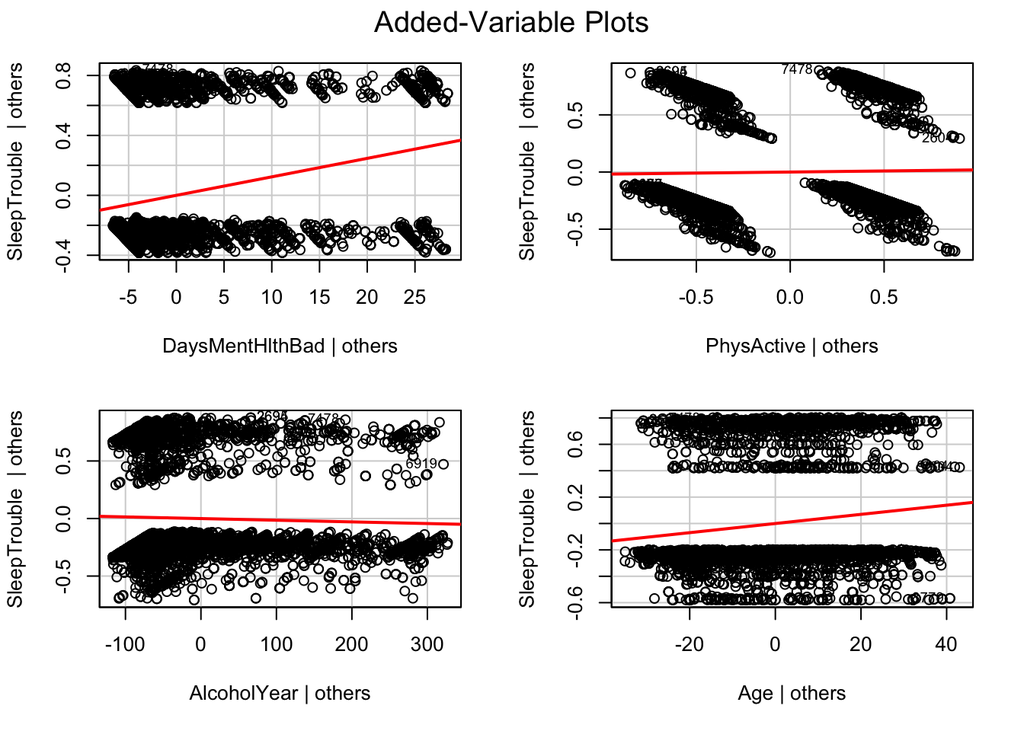

```r
#added variable plots
avPlots(RegModel1, id.n=3, id.cex=0.7)
```

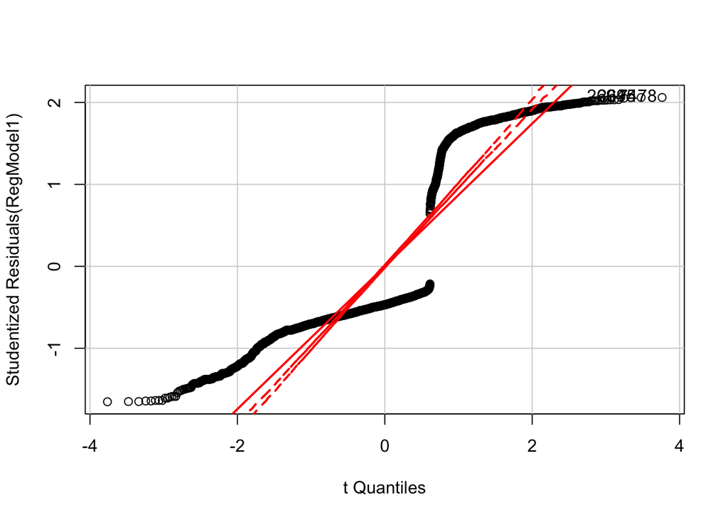

```
## 2694 2695 7478
## 5906 5907 5908
```

```r
# run the qq-plot, observations with large residuals
qqPlot(RegModel1, id.n=3)
```

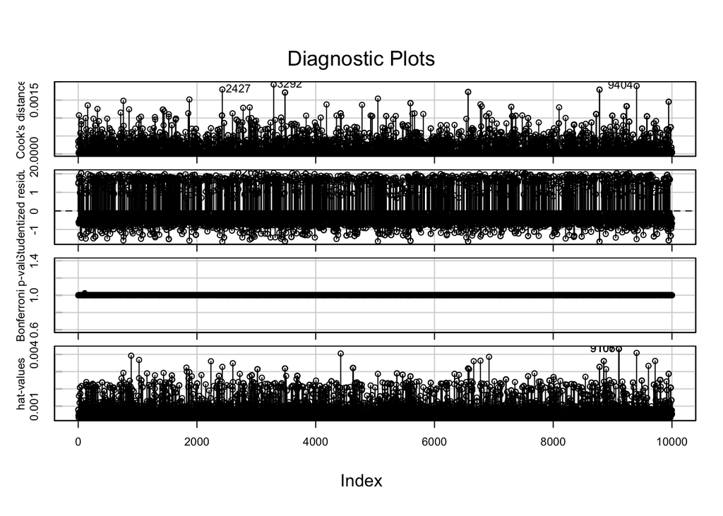

```r
#identify highly influential points
influenceIndexPlot(RegModel1, id.n=3)
```

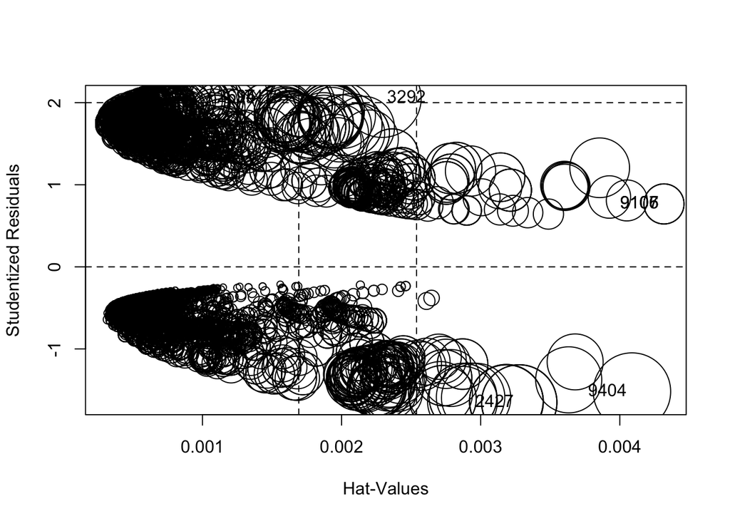

```
##         StudRes         Hat        CookD
## 2427 -1.6531501 0.003276559 0.0017962652
## 2694  2.0607449 0.001068508 0.0009079917
## 2695  2.0607449 0.001068508 0.0009079917
## 3292  2.0529257 0.002290891 0.0019343744
## 7478  2.0614858 0.001262455 0.0010737821
## 9105  0.7663591 0.004317126 0.0005093292
## 9106  0.7663591 0.004317126 0.0005093292
## 9107  0.7663591 0.004317126 0.0005093292
## 9404 -1.5190691 0.004087171 0.0018936092
```

```r
#influence plot
influencePlot(RegModel1, id.n=3)
```

```r
#heteroscedasticity
ncvTest(RegModel1)
```

```
## Non-constant Variance Score Test
## Variance formula: ~ fitted.values
## Chisquare = 117.806    Df = 1     p = 1.911994e-27
```

```r
#multicollinearity
vif(RegModel1)
```

```
## DaysMentHlthBad      PhysActive     AlcoholYear             Age
##        1.022009        1.070837        1.033898        1.060426
```

While I am not quite sure how to interpret these graphs with a binary outcome in a least squares regression, it does seem like there are some problems with assumptions about heteroskedasticity and normality. Logistic regression will probably make a lot more sense (at least as far as visualizing).

**Logistic Regression**

```r
people$SleepTrouble[people$SleepTrouble == 1 ] <- 0
people$SleepTrouble[people$SleepTrouble == 2 ] <- 1
train <- na.omit(people[1:8000,])
test <- na.omit(people[8001:10000,])
model <- glm(SleepTrouble~DaysMentHlthBad + PhysActive + AlcoholYear + Age,family=binomial(link='logit'),data=train)
##Model goes where ~ is, just like lsq
summary(model)
```

```
##
## Call:
## glm(formula = SleepTrouble ~ DaysMentHlthBad + PhysActive + AlcoholYear +
##     Age, family = binomial(link = "logit"), data = train)
##
## Deviance Residuals:
##     Min       1Q   Median       3Q      Max
## -1.6488  -0.7782  -0.6701   1.0206   1.9926
##
## Coefficients:
##                   Estimate Std. Error z value Pr(>|z|)
## (Intercept)     -2.2513067  0.1510641 -14.903   <2e-16 ***
## DaysMentHlthBad  0.0567425  0.0035230  16.106   <2e-16 ***
## PhysActive       0.1058278  0.0630899   1.677   0.0935 .
## AlcoholYear     -0.0007599  0.0002998  -2.534   0.0113 *
## Age              0.0184281  0.0018565   9.926   <2e-16 ***
## ---
## Signif. codes:  0 '***' 0.001 '**' 0.01 '*' 0.05 '.' 0.1 ' ' 1
##
## (Dispersion parameter for binomial family taken to be 1)
##
##     Null deviance: 6889.5  on 5907  degrees of freedom
## Residual deviance: 6548.6  on 5903  degrees of freedom
## AIC: 6558.6
##
## Number of Fisher Scoring iterations: 4
```

```r
##https://www.r-bloggers.com/how-to-perform-a-logistic-regression-in-r/
```

A 1 unit increase in bad mental health days is associated with a .057 increase in the logit of sleep trouble, significant at p<.001. Age and alcohol also have significant relationships, while the coefficient for physical activity is quite high.

**Decision Tree**

```r
library(rpart)
library(tidyverse)

fit<-rpart(SleepTrouble~DaysMentHlthBad + PhysActive + AlcoholYear + Age, data = train, method = "class")

printcp(fit) # Display the results
```

```
##
## Classification tree:
## rpart(formula = SleepTrouble ~ DaysMentHlthBad + PhysActive +
##     AlcoholYear + Age, data = train, method = "class")
##
## Variables actually used in tree construction:
## [1] DaysMentHlthBad
##
## Root node error: 1594/5908 = 0.2698
##
## n= 5908
##
##         CP nsplit rel error  xerror     xstd
## 1 0.019762      0   1.00000 1.00000 0.021403
## 2 0.010000      2   0.96048 0.96989 0.021195
```

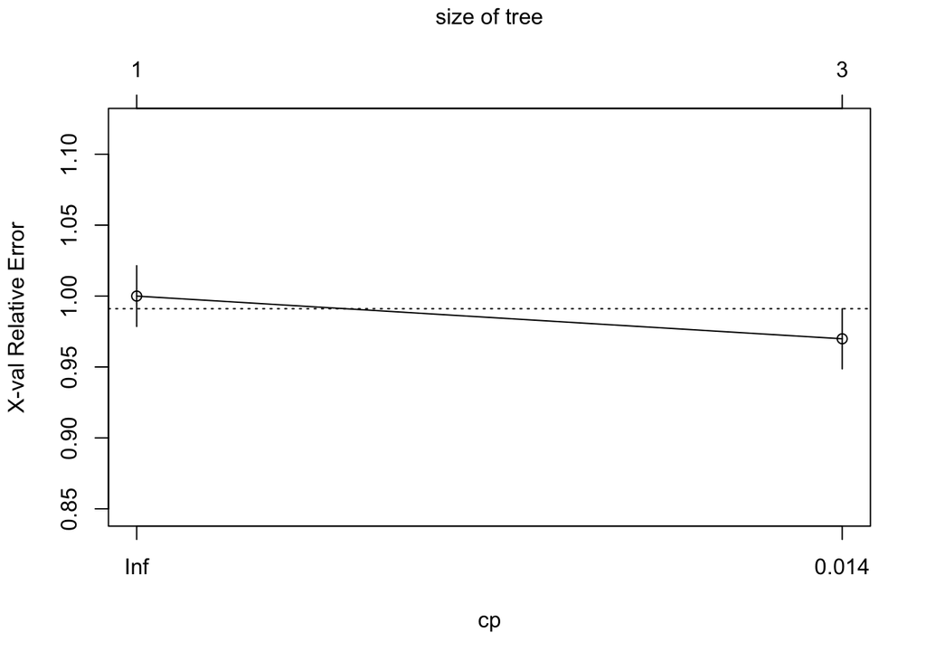

```r
plotcp(fit) # Visualize cross-validation results
```

```r
summary(fit) # Detailed summary of fit
```

```
## Call:
## rpart(formula = SleepTrouble ~ DaysMentHlthBad + PhysActive +
##     AlcoholYear + Age, data = train, method = "class")
##   n= 5908
##
##           CP nsplit rel error    xerror       xstd
## 1 0.01976161      0 1.0000000 1.0000000 0.02140305
## 2 0.01000000      2 0.9604768 0.9698871 0.02119527
##
## Variable importance
## DaysMentHlthBad
##             100
##
## Node number 1: 5908 observations,    complexity param=0.01976161
##   predicted class=0  expected loss=0.2698037  P(node) =1
##     class counts:  4314  1594
##    probabilities: 0.730 0.270
##   left son=2 (3981 obs) right son=3 (1927 obs)
##   Primary splits:
##       DaysMentHlthBad < 2.5  to the left,  improve=78.037370, (0 missing)
##       Age             < 40.5 to the left,  improve=38.314010, (0 missing)
##       AlcoholYear     < 0.5  to the right, improve=10.715450, (0 missing)
##       PhysActive      < 1.5  to the right, improve= 2.270998, (0 missing)
##
## Node number 2: 3981 observations
##   predicted class=0  expected loss=0.213263  P(node) =0.6738321
##     class counts:  3132   849
##    probabilities: 0.787 0.213
##
## Node number 3: 1927 observations,    complexity param=0.01976161
##   predicted class=0  expected loss=0.3866113  P(node) =0.3261679
##     class counts:  1182   745
##    probabilities: 0.613 0.387
##   left son=6 (1582 obs) right son=7 (345 obs)
##   Primary splits:
##       DaysMentHlthBad < 29.5 to the left,  improve=35.215220, (0 missing)
##       Age             < 34.5 to the left,  improve=22.581940, (0 missing)
##       AlcoholYear     < 0.5  to the right, improve=11.784590, (0 missing)
##       PhysActive      < 1.5  to the right, improve= 3.588533, (0 missing)
##
## Node number 6: 1582 observations
##   predicted class=0  expected loss=0.3419722  P(node) =0.2677725
##     class counts:  1041   541
##    probabilities: 0.658 0.342
##
## Node number 7: 345 observations
##   predicted class=1  expected loss=0.4086957  P(node) =0.0583954
##     class counts:   141   204
##    probabilities: 0.409 0.591
```

```r
library(partykit)
fitallp <- ctree(SleepTrouble~DaysMentHlthBad + PhysActive + AlcoholYear + Age, data = train)
print(fitallp)
```

```
##
## Model formula:
## SleepTrouble ~ DaysMentHlthBad + PhysActive + AlcoholYear + Age
##
## Fitted party:
## [1] root
## |   [2] DaysMentHlthBad <= 2
## |   |   [3] Age <= 45
## |   |   |   [4] DaysMentHlthBad <= 0
## |   |   |   |   [5] Age <= 34: 0.100 (n = 861, err = 77.4)
## |   |   |   |   [6] Age > 34: 0.153 (n = 619, err = 80.4)
## |   |   |   [7] DaysMentHlthBad > 0: 0.231 (n = 316, err = 56.1)
## |   |   [8] Age > 45
## |   |   |   [9] AlcoholYear <= 168
## |   |   |   |   [10] DaysMentHlthBad <= 0: 0.276 (n = 1495, err = 298.5)
## |   |   |   |   [11] DaysMentHlthBad > 0: 0.394 (n = 236, err = 56.4)
## |   |   |   [12] AlcoholYear > 168
## |   |   |   |   [13] DaysMentHlthBad <= 0: 0.217 (n = 392, err = 66.6)
## |   |   |   |   [14] DaysMentHlthBad > 0: 0.081 (n = 62, err = 4.6)
## |   [15] DaysMentHlthBad > 2
## |   |   [16] DaysMentHlthBad <= 29
## |   |   |   [17] Age <= 34: 0.254 (n = 568, err = 107.5)
## |   |   |   [18] Age > 34: 0.392 (n = 1014, err = 241.6)
## |   |   [19] DaysMentHlthBad > 29
## |   |   |   [20] AlcoholYear <= 180: 0.555 (n = 292, err = 72.1)
## |   |   |   [21] AlcoholYear > 180: 0.792 (n = 53, err = 8.7)
##
## Number of inner nodes:    10
## Number of terminal nodes: 11
```

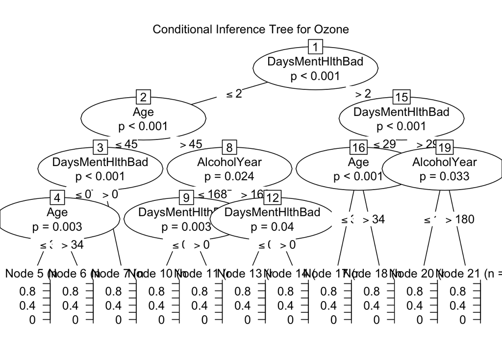

```r
plot(fitallp, main = "Conditional Inference Tree for Ozone")
```

From the output we can see that group with the highest proportion suffering from disturbed sleep is the group that struggles with mental health almost daily. For this group there is an especially high-risk sub-group that struggles with alcohol with a .79 proportion struggling with sleep. Other notably high proportions, ranging between .25 and .4, include individuals older than 45 that drink alcohol moderately or not at all and individuals struggling with mental health 3-29 days out of a month. The lowest risk individuals are younger than 34 with good mental health and older than 45, drinking alcohol regulary (interesting), and having only 1 day a month of bad mental health.

**Random forest**

```r
library(randomForest)
set.seed(131)

fitallrf <- randomForest(SleepTrouble ~ DaysMentHlthBad + PhysActive + AlcoholYear + Age, data = train, importance = TRUE)
impallrf <- importance(fitallrf)
```

**Effectiveness** **Visualization**

```r
# view the results
print(fitallrf)
```

```
##
## Call:
##  randomForest(formula = SleepTrouble ~ DaysMentHlthBad + PhysActive +      AlcoholYear + Age, data = train, importance = TRUE)
##                Type of random forest: regression
##                      Number of trees: 500
## No. of variables tried at each split: 1
##
##           Mean of squared residuals: 0.1724557
##                     % Var explained: 12.46
```

```r
importance(fitallrf)
```

```
##                  %IncMSE IncNodePurity
## DaysMentHlthBad 48.18317     65.628117
## PhysActive      32.84701      5.133698
## AlcoholYear     31.64171     33.830667
## Age             37.05503     56.554576
```

I’m not sure what these outcomes mean exactly. It looks like it struggled to make many splits.

k-nearest neighbor **Building model**

```r
# Create the grid

ages <- range(~ Age, data = people)
menthealth <- range(~ Age, data = people)
res <- 100
fake_grid <- expand.grid(
  Age = seq(from = ages[1], to = ages[2], length.out = res),
  DaysMentHlthBad = seq(from = menthealth[1], to = menthealth[2], length.out = res))

#Get the overall proportion, p, of Diabetics

p <- sum(people$SleepTrouble == 1)/length(people$SleepTrouble)

# Null model prediction

pred_null <- rep(p, nrow(fake_grid))

# reinitialize the people dataset - fix SleepTrouble
# back to factor of "Yes" and "No"

people <- NHANES[, c("Age", "DaysMentHlthBad", "AlcoholYear",
                     "PhysActive", "SleepTrouble")]
people <- na.omit(people)
#people <- as.data.frame(people)

people <- NHANES %>%
  dplyr::select(SleepTrouble, Age, DaysMentHlthBad, AlcoholYear, PhysActive) %>%
  na.omit()

form <- as.formula("SleepTrouble ~ Age+ DaysMentHlthBad")

# Evaluate each model on each grid point
# For the decision tree

dmod_tree <- rpart(form, data = people,
                   control = rpart.control(cp = 0.005, minbucket = 30))

# For the forest

set.seed(20371)
#dmod_forest <- rfsrc(form, data = people,
#                     ntree = 201, mtry = 3)
# try with randomForest instead of randomForestSRC package
library(randomForest)
dmod_forest <- randomForest(form, data = people,
                     ntree = 201, mtry = 2)

# Now the predictions for tree and forest

pred_tree <- predict(dmod_tree, newdata = fake_grid)[, "Yes"]
# pred_tree <- predict(dmod_tree, newdata = fake_grid)[, 1]
pred_forest <- predict(dmod_forest, newdata = fake_grid,
                       type = "prob")[, "Yes"]

# K-nearest neighbor prediction

pred_knn <- people %>%
  select(Age, DaysMentHlthBad) %>%
  knn(test=select(fake_grid, Age, DaysMentHlthBad), cl = people$SleepTrouble, k=5) %>%
  as.numeric() - 1
```

**Effectiveness** Now let’s see how well it classifies

```r
# Calculate the percent predicted correctly

#people$SleepTrouble <- as.numeric(people$SleepTrouble)
# Let's try different values of k to see how that affects performance

#knn.1 <- knn(train = people, test = people, cl = train, as.numeric(people$Diabetes), k = 1)
#knn.3 <- knn(train = people, test = people, cl = people$Diabetes, k = 3)
#knn.5 <- knn(train = people, test = people, cl = people$Diabetes, k = 5)
#knn.20 <- knn(train = people, test = people, cl = people$Diabetes, k = 20)

#knn.1

#100*sum(people$SleepTrouble == knn.1)/length(knn.1)
#100*sum(people$SleepTrouble == knn.3)/length(knn.3)
#100*sum(people$SleepTrouble == knn.5)/length(knn.5)
#100*sum(people$SleepTrouble == knn.20)/length(knn.20)
```

```r
# Another way to look at success rate against increasing k

#table(knn.1, people$SleepTrouble)
#table(knn.3, people$SleepTrouble)
#table(knn.5, people$SleepTrouble)
#table(knn.20, people$SleepTrouble)
```

Couldn’t get past an error with class in the beginning of the code.

2. Repeat problem 1 except now you are to use the quantitative variable called SleepHrsNight. The model types are as follows: null model, multiple regression, regression tree, random forest.